# ISA 401: Business Intelligence & Data Visualization

## 15: Fundamentals of Data Visualization

### Fall 2026

# Before We Start

1 Join today's Zoom

Use the Zoom link in the [**Week 0 Module**](https://miamioh.instructure.com/courses/258169/modules/981092) on Canvas. **Mute** your mic and **turn off** your video.  
There is no R today. Keep a piece of paper and a pen ready: one activity asks you to sketch a chart.

2 Today's plan

**35 min.** Graphical excellence and graphical integrity.  
**10 min.** Data-ink and chartjunk.  
**18 min.** Data types and visual encoding.  
**7 min.** Color.  
**Monday:** we turn these principles into ggplot2 code.

# Where We Are

ISA 401

↓

Phase I

**Data Acquisition & Transformation**  
Aug 24 to Oct 12 (ends with Exam 01)

Phase II (we are here)

**Data Visualization & Communication**  
Oct 14 to Nov 16 (ends with Exam 02)

Phase III

**Exploratory Data Mining & Project Synthesis**  
Nov 18 to Dec 2

**Phase II starts today.** We collected and cleaned data in Phase I. Now we decide how to show it.

Phase names and dates from the course schedule on Canvas.

# Learning Objectives

By the end of today, you should be able to:

1. **Explain** Tufte's principles of graphical excellence.

2. **Select** appropriate visual encodings based on data types.

3. **Apply** color theory and accessibility guidelines.

4. **Identify** and critique misleading visualizations.

# Part 1: Graphical Excellence

# Terrible Charts

<countdown-timer class="countdown" id="timer_3abfc0cb" minutes="5" seconds="0" update-every="1" tabindex="0" style="top:0;right:0;--countdown-font-size:2em;"></countdown-timer>

.panel[Task

**Task.** In 5 minutes, find the **one or two main problems** in each of the three charts in the next tabs.

- Write your answers in the box under each chart.

- Compare your answers with the person next to you.

- Be ready to share them with the class.

.panel[Russia's Defense Budget

[figure not shown]

- Edit me to include the main issue(s)

Source: shared by Cédric Scherer in [this post](https://x.com/CedScherer/status/1498593405408059394); the outlet that made the original chart is unclear.

.panel[White House Growth

[figure not shown]

- Edit me to include the main issue(s)

Source: posted by the White House in [this post](https://x.com/WhiteHouse/status/1486709480351952901). The chart was later corrected.

.panel[Fox News

[figure not shown]

- Edit me to include the main issue(s)

Source: shown in [this Fox News clip](https://video.foxnews.com/v/6274513508001).

.panel[Answer

<details class="answer-gate">
<summary>Show the answer</summary>

<table>
<thead><tr><th>Chart</th><th>Main issue</th></tr></thead>
<tbody>
<tr><td>Russia's Defense Budget</td><td>Each square's side is proportional to the budget, but we read area. The budgets differ by a factor of 14.0, so Russia's square looks about 197 times larger.</td></tr>
<tr><td>White House Growth</td><td>The y-axis steps by 1 up to 5% and then by 0.5, so the 2021 bar (5.7%) reaches where about 6.4% would sit on an even scale. The 2020 contraction right before it also gives the rebound context the chart leaves out.</td></tr>
<tr><td>Fox News</td><td>The y-axis starts at 58, and its labels sit on the right side. 77% to 65% is a 12-percentage-point drop, a 15.6% decline, but the bars (19 vs. 7 units above 58) show a 63% drop. Bars should start at 0.</td></tr>
</tbody>
</table>

</details>

.panel[Discussion

- Edit me to include any notes/discussion

# What Should Graphs Do?

1**Show the data.**

2Lead the viewer to think about the **substance** rather than something else.

3Avoid **distorting** what the data have to say.

4Present **many numbers in a small space**.

5Make **large datasets coherent**.

6Encourage the eye to **compare** different pieces of data.

7Reveal the data at **several levels of detail**, from a broad overview to the fine structure.

8Serve a **clear purpose**: description, exploration, tabulation, or decoration.

9Be closely **integrated with the statistical and verbal descriptions** of the data.

**Tufte lists nine things that graphs should do.** Press Step to go through them one at a time. Each step shows a less effective chart next to a better one, made from real data.

The slides after this one go deeper into the first three.

**1. Show the data.** A summary alone can hide what the data look like. Anscombe's Set 2 is a curve, not a line.

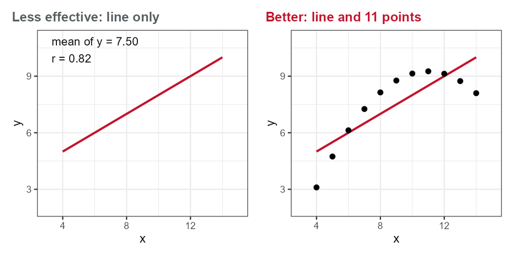

**2. Think about the substance.** The reader should think about the numbers, not the colors or the effects. Russia and Ukraine defense budgets, 2020.

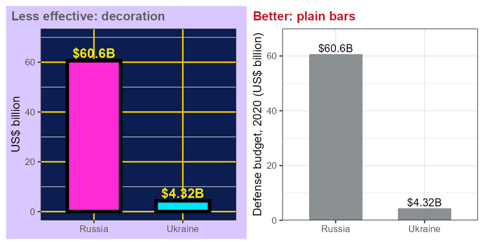

**3. Avoid distortion.** Bar lengths should match the numbers. Same two values as the Fox News chart.

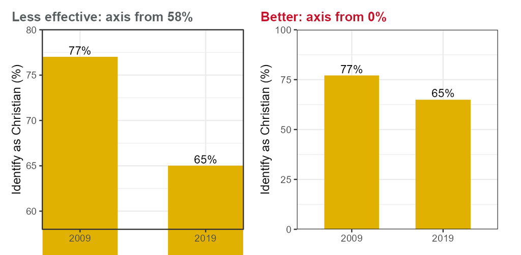

**4. Many numbers in a small space.** The same space can hold the 3 means (triangles, labeled with their values) and all 684 measurements.

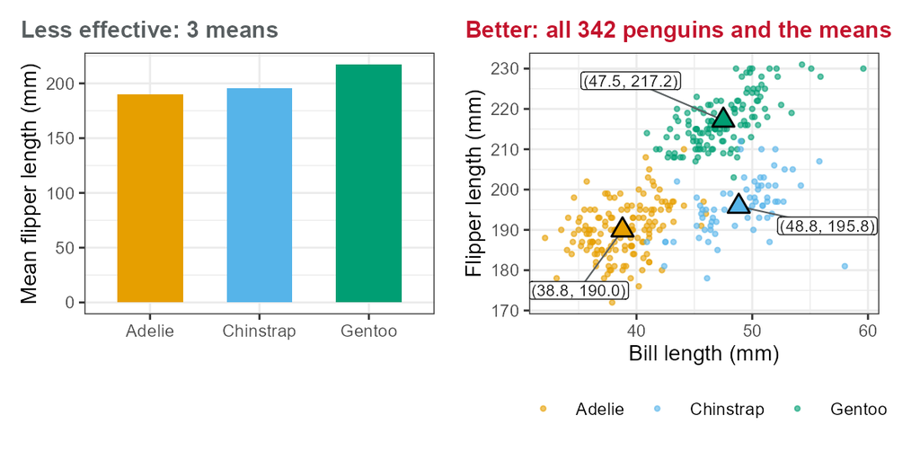

**5. Make large datasets coherent.** On a map, the 48 murder rates of 1976 form a regional pattern: 8 of the 10 highest are in the South (Census region). Color shows the pattern, not exact values.

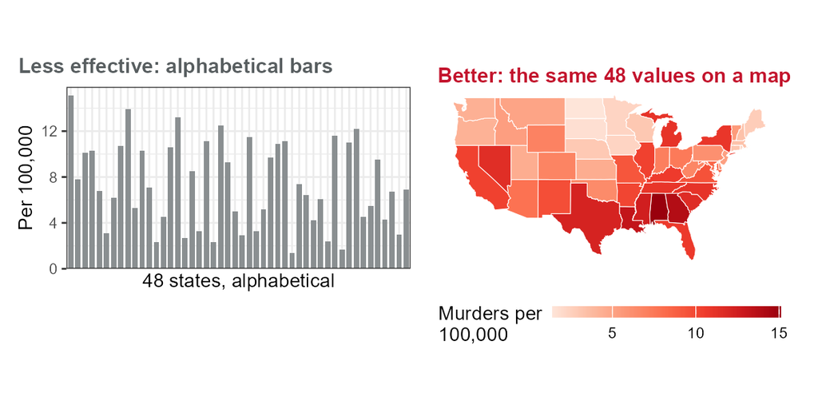

**6. Encourage comparison.** Values to be compared belong on a common scale.

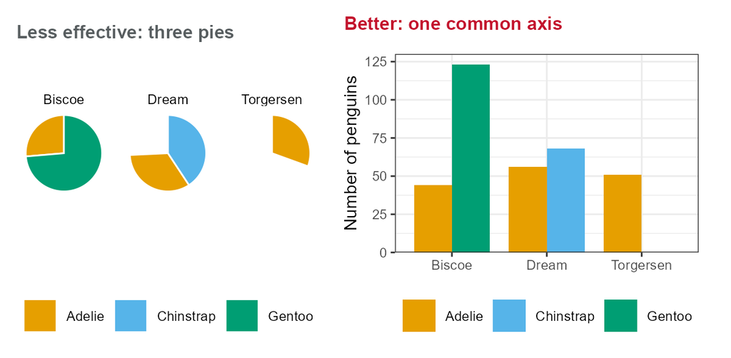

**7. Several levels of detail.** The overview and the detail in one graph.

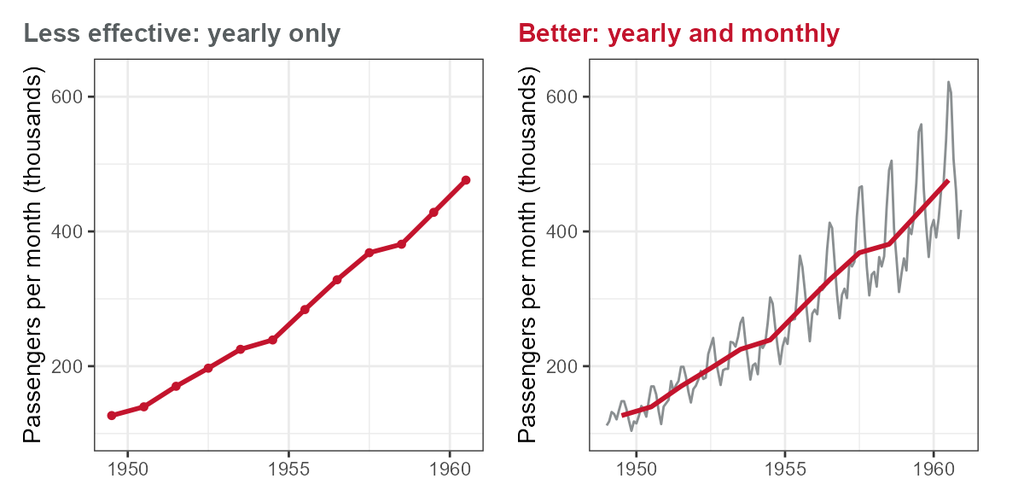

**8. Serve a clear purpose.** Description, exploration, tabulation, or decoration. Same numbers, two purposes.

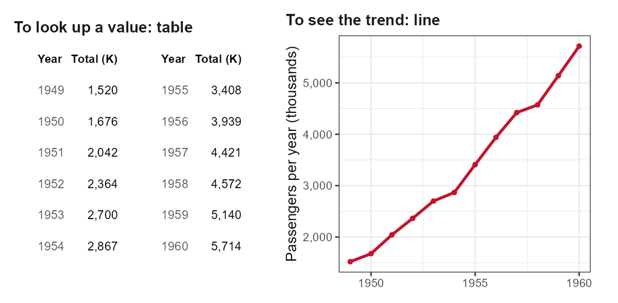

**9. Integrate with the statistics and the text.** The title and labels say what the graph shows.

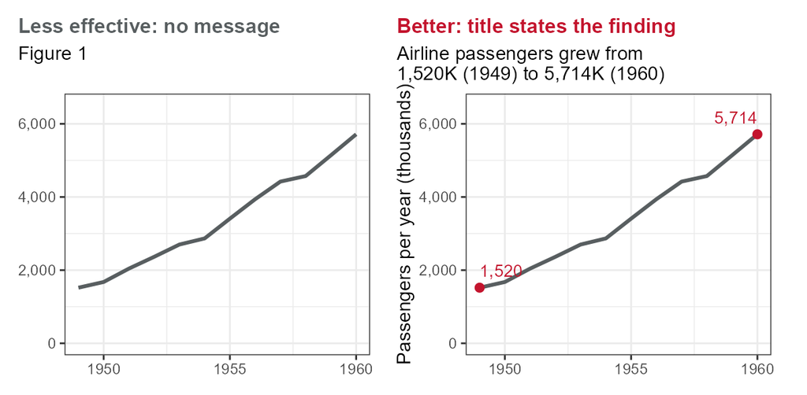

0 / 9

Source: Tufte, E. R. (2001). *The Visual Display of Quantitative Information* (2nd ed.). Cheshire, CT: Graphics Press, p. 13.

# Show the Data: Anscombe's Quartet

**In a seminal paper, Anscombe wrote:**

> **Few of us escape being indoctrinated with these notions:**
>  - numerical **calculations are exact, but graphs are rough**;
>  - for any particular kind of **statistical data there is just one set of calculations constituting a correct statistical analysis**;
>  - performing **intricate calculations is virtuous**, whereas **actually looking at the data is cheating**.

He then argued that

> a computer should **make both calculations and graphs**. Both sorts of output should be studied; each will contribute to understanding.

Source: Anscombe, F. J. (1973). Graphs in Statistical Analysis. *The American Statistician*, 27(1), 17-21 ([PDF](https://www.sjsu.edu/faculty/gerstman/StatPrimer/anscombe1973.pdf)).

# Show the Data: Anscombe's Statistics

.panel[Summary statistics

**Question.** Anscombe built four datasets of eleven (x, y) points each. Their summaries are below. Are these four datasets alike?

| Set | Mean of x | SD of x | Mean of y | SD of y | Correlation |
| --- | --- | --- | --- | --- | --- |
| Set 1 | 9.00 | 3.32 | 7.50 | 2.03 | 0.82 |
| Set 2 | 9.00 | 3.32 | 7.50 | 2.03 | 0.82 |
| Set 3 | 9.00 | 3.32 | 7.50 | 2.03 | 0.82 |
| Set 4 | 9.00 | 3.32 | 7.50 | 2.03 | 0.82 |

.panel[The 44 points

| x1 | y1 | x2 | y2 | x3 | y3 | x4 | y4 |
| --- | --- | --- | --- | --- | --- | --- | --- |
| 10 | 8.04 | 10 | 9.14 | 10 | 7.46 | 8 | 6.58 |
| 8 | 6.95 | 8 | 8.14 | 8 | 6.77 | 8 | 5.76 |
| 13 | 7.58 | 13 | 8.74 | 13 | 12.74 | 8 | 7.71 |
| 9 | 8.81 | 9 | 8.77 | 9 | 7.11 | 8 | 8.84 |
| 11 | 8.33 | 11 | 9.26 | 11 | 7.81 | 8 | 8.47 |
| 14 | 9.96 | 14 | 8.10 | 14 | 8.84 | 8 | 7.04 |
| 6 | 7.24 | 6 | 6.13 | 6 | 6.08 | 8 | 5.25 |
| 4 | 4.26 | 4 | 3.10 | 4 | 5.39 | 19 | 12.50 |
| 12 | 10.84 | 12 | 9.13 | 12 | 8.15 | 8 | 5.56 |
| 7 | 4.82 | 7 | 7.26 | 7 | 6.42 | 8 | 7.91 |
| 5 | 5.68 | 5 | 4.74 | 5 | 5.73 | 8 | 6.89 |

# Show the Data: Anscombe's Scatterplots

[figure not shown]

**The four datasets have the same summary statistics but different patterns.** Set 1 is a noisy line, Set 2 is a curve, Set 3 is a line with one outlier, and in Set 4 one point sets the slope. The fitted red line is the same in all four.

# Show the Data: The Datasaurus

[figure not shown]

Source: Matejka, J. and Fitzmaurice, G. (2017). Same Stats, Different Graphs: Generating Datasets with Varied Appearance and Identical Statistics through Simulated Annealing. *Proceedings of the 2017 CHI Conference on Human Factors in Computing Systems* ([project page](https://www.research.autodesk.com/publications/same-stats-different-graphs/)).

# Substance: Playfair's Cities

<countdown-timer class="countdown" id="timer_f1db27b2" minutes="5" seconds="0" update-every="1" tabindex="0" style="top:0;right:0;--countdown-font-size:2em;"></countdown-timer>

.panel[Task

**Task.** In 5 minutes, **sketch** a better (non-bubble) chart than this one by William Playfair, which shows the populations of 22 European cities at the end of the 1700s.

[figure not shown]

.panel[Your Solution

**Sketch your solution on paper.** If you prefer software, the code below downloads the data and saves it as a CSV file. It is optional.

[output not shown]

**Be ready to share your sketch with the class.**

.panel[My Solution

<details class="answer-gate">
<summary>Show my solution</summary>
In my opinion, a <strong>dot chart works better</strong> than the bubble chart. Population is encoded by <strong>position</strong>; area can stay as a second encoding.
<img src="data:…" alt="" width="70%" style="display: block; margin: auto;" />
</details>

.panel[Discussion

- Edit me to include any notes/discussion

# Avoid Distortion: A Chart from Tufte's Book

[figure not shown]

Source: Tufte, E. R. (2001). *The Visual Display of Quantitative Information* (2nd ed.). Graphics Press, p. 54.

# Avoid Distortion: A Fox Business Chart

[figure not shown]

Source: Yau, N. (2012). [Fox News continues charting excellence](https://flowingdata.com/2012/08/06/fox-news-continues-charting-excellence/). FlowingData.

# Avoid Distortion: The Lie Factor

[figure not shown]

Source: Tufte, E. R. (2001). *The Visual Display of Quantitative Information* (2nd ed.). Graphics Press, p. 57.

# Avoid Distortion: Calculating the Lie Factor

**Both "effects" are a percent change:** (new value − old value) / old value. Both sets of numbers are printed on Tufte's figure.

Effect in the data18 mpg in 1978 to 27.5 mpg in 1985:27.5 − 1818=0.53 (53%)

Effect in the graphica line 0.6 inches long to a line 5.3 inches long:5.3 − 0.60.6=7.83 (783%)

Lie factoreffect in the graphiceffect in the data=7.830.53=14.8

**A lie factor of 1 means the graphic is honest.** Tufte treats values above 1.05 or below 0.95 as substantial distortion. This chart shows the change about 15 times larger than it was.

Source: Tufte, E. R. (2001). *The Visual Display of Quantitative Information* (2nd ed.). Graphics Press, p. 57.

# Avoid Distortion: A Summary

Label clearly

Clear, detailed, and thorough labeling, with appropriate scales.

Keep the lie factor near 1

The size of the effect in the graphic should be directly proportional to the numbers it represents.

Show data variation

Variation in the graphic should come from the data, not from the design.

Based on Tufte, E. R. (2001). *The Visual Display of Quantitative Information* (2nd ed.). Graphics Press, ch. 2.

# Part 2: Theory of Data Graphics

# The Data-Ink Ratio

**Data-ink** is the non-erasable ink used to present the data. If the data-ink were removed, the graphic would lose its content.

Data-ink ratio=data-inktotal ink used to print the graphic

=the proportion of a graphic's ink devoted to the non-redundant display of data information

=1 − the proportion of a graphic that can be erased without losing data information

Source: Tufte, E. R. (2001). *The Visual Display of Quantitative Information* (2nd ed.). Graphics Press, ch. 4.

# The Data-Ink Ratio

**Data-ink** is the non-erasable ink used to present the data. If the data-ink were removed, the graphic would lose its content.

[figure not shown]

Source: adapted from Hanspeter Pfister, lecture notes for CS 171, Harvard University. [cs171.org](http://cs171.org/)

# The Data-Ink Ratio

**Data-ink** is the non-erasable ink used to present the data. If the data-ink were removed, the graphic would lose its content.

[figure not shown]

Source: adapted from Hanspeter Pfister, lecture notes for CS 171, Harvard University. [cs171.org](http://cs171.org/)

# Focus on Data: Avoid Chartjunk

**Chartjunk is the extraneous visual elements that distract from the message.**

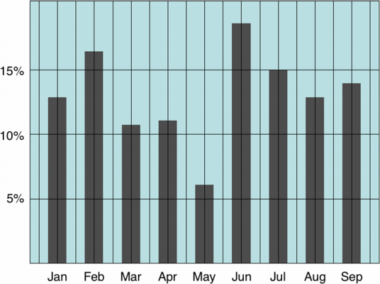

Source: Tim Bray, [The Data-Ink Ratio Example](http://www.tbray.org/ongoing/data-ink/di1) (step 1 of 6).

# Focus on Data: Avoid Chartjunk

**Chartjunk is the extraneous visual elements that distract from the message.**

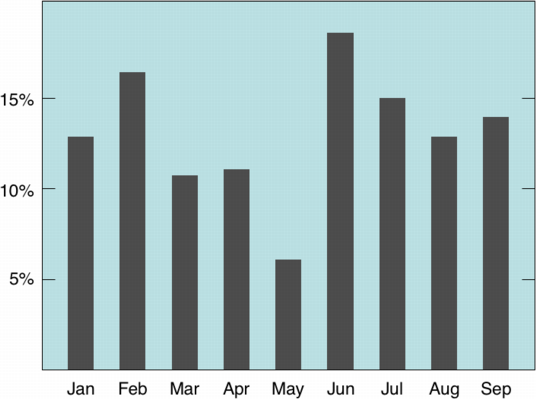

Source: Tim Bray, [The Data-Ink Ratio Example](http://www.tbray.org/ongoing/data-ink/di2) (step 2 of 6).

# Focus on Data: Avoid Chartjunk

**Chartjunk is the extraneous visual elements that distract from the message.**

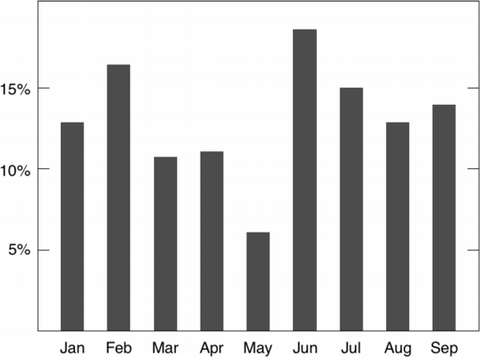

Source: Tim Bray, [The Data-Ink Ratio Example](http://www.tbray.org/ongoing/data-ink/di3) (step 3 of 6).

# Focus on Data: Avoid Chartjunk

**Chartjunk is the extraneous visual elements that distract from the message.**

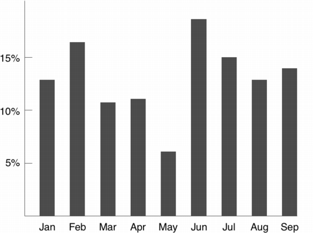

Source: Tim Bray, [The Data-Ink Ratio Example](http://www.tbray.org/ongoing/data-ink/di4) (step 4 of 6).

# Focus on Data: Avoid Chartjunk

**Chartjunk is the extraneous visual elements that distract from the message.**

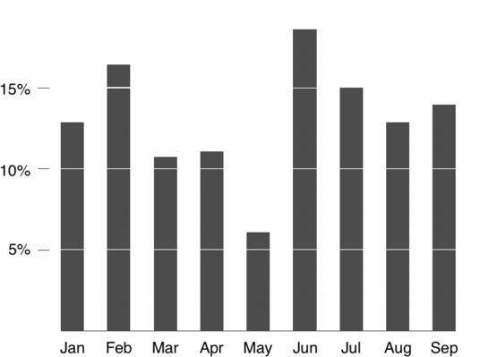

Source: Tim Bray, [The Data-Ink Ratio Example](http://www.tbray.org/ongoing/data-ink/di5) (step 5 of 6).

# Focus on Data: Avoid Chartjunk

**Chartjunk is the extraneous visual elements that distract from the message.**

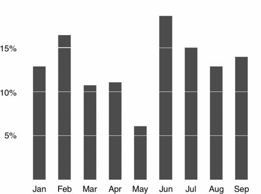

Source: Tim Bray, [The Data-Ink Ratio Example](http://www.tbray.org/ongoing/data-ink/di6) (step 6 of 6).

# Other Design Considerations

Subjective principles (Pat Hanrahan)

**Aesthetics:** attractive things are perceived as more useful than unattractive ones.

**Style:** communicates brand, process, and who the designer is.

**Playfulness:** encourages experimentation and exploration.

**Vividness:** can make a visualization more memorable.

Is chartjunk always bad?

Bateman et al. (2010) compared embellished charts with plain ones. People described the embellished charts **no less accurately**, and **remembered them significantly better** after two to three weeks.

Maximizing the data-ink ratio is a guideline, not a law. Decoration that does not distort the data can help a chart be remembered.

Sources: Pfister, CS 171 lecture notes, based on comments by Pat Hanrahan (2007), discussed at perceptualedge.com/blog/?p=199. Bateman, S., et al. (2010). [Useful junk? The effects of visual embellishment on comprehension and memorability of charts](https://vis.csail.mit.edu/classes/6.859/readings/pdfs/Bateman-UsefulJunk.pdf). *CHI 2010*, [doi:10.1145/1753326.1753716](https://doi.org/10.1145/1753326.1753716).

# Part 3: Data Types and Visual Encoding

# Stevens (1946): Scales of Measurement

[figure not shown]

Source: Stevens, S. S. (1946). On the Theory of Scales of Measurement. *Science*, 103(2684), 677-680.

# Data Types (from S. Stevens, Theory of Scales)

[figure not shown]

# Data Types: Explained

Nominal

Values are = or ≠ to other values.  
Apples, bananas, oranges, etc.

Ordinal

Values obey a < relationship.  
Small, medium, and large.

Quantitative

We can do math on them.  
50 inches, 53 inches, etc.

[figure not shown]

# Quantitative Data: Interval or Ratio?

Interval: the location of zero is arbitrary

Dates (Jan 19), locations (latitude, longitude), temperature in °F.

Only **differences** (intervals) can be compared.

**Test:** is 40°F twice as warm as 20°F? **No.** 0°F is not "no temperature", so the ratio means nothing. The difference of 20°F does mean something.

Ratio: zero is fixed

Measurements: length, weight, cost, counts.

The origin is meaningful, so **ratios, proportions, and differences** can all be computed.

**Test:** is $40 twice as much as $20? **Yes.** $0 means no money, so "twice as much" is meaningful.

**Why it matters for charts:** a bar's length shows a value as a distance from zero. That works for ratio data. For interval data, a bar from zero has no meaning, so we use positions (dots, lines) instead.

# Data Terminology

<countdown-timer class="countdown" id="timer_fd223a75" minutes="2" seconds="0" update-every="1" tabindex="0" style="top:0;right:0;--countdown-font-size:2em;"></countdown-timer>

.panel[Task

**Task.** In 2 minutes, identify the data type (nominal, ordinal, interval, or ratio) of each column.

| Order ID | Order Date | Order Priority | Product Container | Product Cost | Ship Date |
| --- | --- | --- | --- | --- | --- |
| 1 | 1/1/2022 | 5 - low | Large box | 25 | 1/5/2022 |
| 2 | 1/4/2022 | 4 - not specified | Small Box | 36 | 1/7/2022 |
| 3 | 1/15/2022 | 2- high | Small Box | 38 | 1/17/2022 |
| 3 | 1/15/2022 | 2- high | Small Box | 41 | 1/17/2022 |
| 3 | 1/15/2022 | 2- high | Jumbo Box | 44 | 1/17/2022 |
| 3 | 1/15/2022 | 2- high | Wrap Bag | 33 | 1/17/2022 |
| 4 | 1/18/2022 | 1- urgent | Small Box | 33 | 1/19/2022 |
| 5 | 1/20/2022 | 3- medium | Medium Box | 40 | 1/23/2022 |
| 5 | 1/20/2022 | 3- medium | Small Box | 16 | 1/23/2022 |
| 5 | 1/20/2022 | 3- medium | Large box | 38 | 1/23/2022 |
| 6 | 1/21/2022 | 1- urgent | Wrap Bag | 7 | 1/22/2022 |

.panel[Your Answer

- Order ID: ________________
- Order Date / Ship Date: ________________
- Order Priority: ________________
- Product Container: ________________
- Product Cost: ________________

.panel[Answer

<details class="answer-gate">
<summary>Show the answer</summary>

<table>
<thead><tr><th>Column</th><th>Type</th><th>Why</th></tr></thead>
<tbody>
<tr><td>Order ID</td><td>Nominal</td><td>A label. Order 6 is not "more" than order 3, and averaging IDs means nothing.</td></tr>
<tr><td>Order Date, Ship Date</td><td>Interval</td><td>The difference (days to ship) is meaningful; a ratio of two dates is not. "Quantitative" is also accepted.</td></tr>
<tr><td>Order Priority</td><td>Ordinal</td><td>Urgent, high, medium, low has an order, but the gaps between levels are not equal amounts.</td></tr>
<tr><td>Product Container</td><td>Nominal or ordinal</td><td>Small, medium, large, and jumbo box have an order, so ordinal can be argued. A wrap bag has no place in that order, so with it in the column, nominal is the safer answer.</td></tr>
<tr><td>Product Cost</td><td>Ratio</td><td>$0 means no cost, so $40 is twice $20.</td></tr>
</tbody>
</table>

</details>

.panel[Discussion

- Edit me to include any notes/discussion

# Data vs. Conceptual Models

1 Data model

32.5, 54.0, −17.3, ...

Numbers in a column.

→

2 Conceptual model

Temperature

What the numbers mean.

→

3 Data type we choose

Continuous to x significant digits: **quantitative**

Hot, warm, cold: **ordinal**

Burned vs. not burned: **nominal**

**The same column can become different data types,** depending on the question we ask. The type we choose decides which visual encodings fit.

# Image Model: Visual (Encoding) Variables

[figure not shown]

Source: Bertin, J. (1967). *Sémiologie graphique*. Paris: Gauthier-Villars.

# Mapping to Data Types

[figure not shown]

Source: adapted from Hanspeter Pfister, lecture notes for CS 171, Harvard University. [cs171.org](http://cs171.org/)

# Visual Channels and Their Precision

[figure not shown]

Source: Franconeri, S. L., et al. (2021). [The Science of Visual Data Communication: What Works](https://doi.org/10.1177/15291006211051956). *Psychological Science in the Public Interest*, 22(3), 110-161.

# Part 4: Color Should Be Used Sparingly

# Simultaneous Contrast Affects Perception

[figure not shown]

Source: adapted from Hanspeter Pfister, lecture notes for CS 171, Harvard University. [cs171.org](http://cs171.org/)

# Color Vision Deficiency

[figure not shown]

"About 1 in 12 men have color vision deficiency." ([National Eye Institute](https://www.nei.nih.gov/learn-about-eye-health/eye-conditions-and-diseases/color-blindness))

**Top row:** under simulated deuteranopia, the red / green palette turns all three species into similar olive browns.

**Bottom row:** the Okabe-Ito palette keeps the three species apart.

**How to accommodate it:** use color sparingly, and use color-blind-safe palettes (e.g., [ColorBrewer](https://colorbrewer2.org/) with "colorblind safe" checked).

Not color blind? [This test](https://enchroma.com/pages/test) gives a feel for it.

Data: `datasets::penguins` (Palmer Station LTER). Simulation: `colorspace::deutan()`.

# Color Brewer: Color Scales and Their Selection

[figure not shown]

**Pick a palette:** [colorbrewer2.org](https://colorbrewer2.org/) lets you choose the number of classes and the scheme type, and filter for colorblind-safe palettes.

Source: Brewer, C. A. (1999). Color Use Guidelines for Data Representation. *Proceedings of the Section on Statistical Graphics*, American Statistical Association.

# Recap

# Summary of Main Points

By now, you should be able to do the following:

- **Explain** Tufte's principles of graphical excellence: show the data, keep the focus on substance, and avoid distortion (Anscombe, Playfair, the data-ink ratio).

- **Select** visual encodings based on data types: nominal, ordinal, interval, or ratio, with position as the channel we perceive most accurately.

- **Apply** color sparingly, choose sequential, diverging, or qualitative scales to match the data, and use palettes that work for color-blind readers.

- **Identify** and critique misleading visualizations, including with the lie factor.

# Before Next Class

Suggested

[**The Lie Factor and the Baseline Paradox**](https://nightingaledvs.com/the-lie-factor-and-the-baseline-paradox/) (de Boer, 2021, Nightingale).

Note what the author means by "baseline", and when the lie factor can mislead for time series and ratio data.

Wilke, *Fundamentals of Data Visualization*: [**ch. 4, Color scales**](https://clauswilke.com/dataviz/color-basics.html) and [**ch. 19, Common pitfalls of color use**](https://clauswilke.com/dataviz/color-pitfalls.html).

Free online. Chapter 19 includes designing for color-vision deficiency.

Skim if curious

[**Useful junk? The effects of visual embellishment on comprehension and memorability of charts**](https://vis.csail.mit.edu/classes/6.859/readings/pdfs/Bateman-UsefulJunk.pdf) (Bateman et al., CHI 2010).

The experiment behind the "Is chartjunk always bad?" card. The paper uses "ratio" differently from how we used it today.

**Monday, Oct 19:** we apply today's principles in code with ggplot2.